# A gut microbiota under antibiotics: stability from a fitted model and from data

Author

Simon Frost

## Overview

Stein et al. (2013) fitted a generalised Lotka–Volterra (gLV) model to the intestinal microbiota of mice. They used 11 genera from 9 mice: some were given a single dose of clindamycin, and some were also given *Clostridium difficile* spores. The fit includes each genus’s susceptibility to the antibiotic. This makes it a rare empirical system with both an interaction matrix and a recorded pulse perturbation.

This vignette uses the published fit to show the package’s interaction-matrix layer:

- the fitted `AlphaMatrix` and why its full equilibrium is not feasible;
- assembling the community the model predicts (`steady_state`, `subcommunity`, `invasion_rates`);
- the stability metrics of that community (`jacobian_profile`);
- the clindamycin pulse, simulated with `glv_trajectory` and compared with the mice;
- what can be estimated from the time series alone (`smap_jacobians`, `invariability`).

The conclusion is mostly negative. These data are too short, and the fit too loose, to validate resilience metrics. The vignette shows why, and what would be needed.

```julia
using CommunityMatrices
using DataFrames, Statistics, LinearAlgebra, Random, Printf
using Plots
st = read_stein(joinpath(pkgdir(CommunityMatrices), "data", "stein2013"))
a, ε, obs = st.alpha, st.susceptibility, st.data
genera = taxa(a)
short(x) = replace(x, "undefined_genus_of_unclassified_" => "u.g. ", "undefined_genus_of_" => "u.g. ",
                   "unclassified_" => "uncl. ", "Clostridium_difficile" => "C. difficile", "_" => " ")
(genera = nspecies(a), samples = nrow(unique(obs[:, [:mouse, :time]])), mice = length(unique(obs.mouse)))
```

```
(genera = 11, samples = 77, mice = 9)
```

The data are bundled in `data/stein2013/` with their provenance: the published fit (Dataset S1 of the article, CC BY 4.0) and the time series (from the cLV repository, MIT). `read_stein` returns the fit as an `AlphaMatrix`, with the units and source recorded in its metadata:

```julia
matrix_metadata(a).derivation, matrix_metadata(a).units
```

```
("Stein et al. 2013, Dataset S1 sheet MmuE (published regularised fit)", "per day")
```

## The fitted interaction matrix

In the model, dNᵢ/dt = Nᵢ (rᵢ + Σⱼ Aᵢⱼ Nⱼ + εᵢ u(t)), where u(t) is the clindamycin signal. Abundances are in 10¹¹ 16S copies per cm³ and time is in days.

```julia
A = matrix(a)
off = A[.!I(nspecies(a))]
(self_regulated = all(<(0), diag(A)), positive = count(>(0), off), negative = count(<(0), off))
```

```
(self_regulated = true, positive = 45, negative = 65)
```

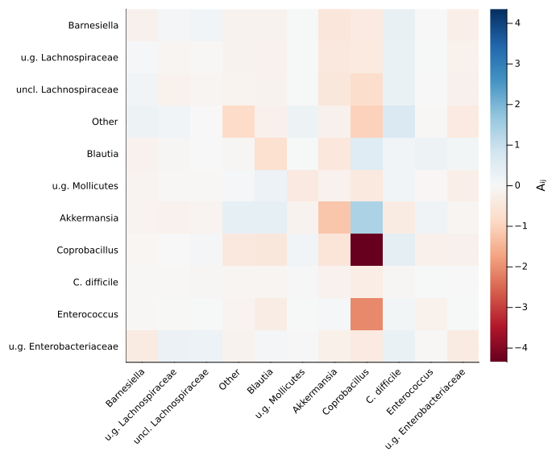

The published interaction matrix: the effect of the column genus on the per-capita growth of the row genus. Rows are sorted by clindamycin susceptibility, most harmed at the top.

```julia
lim = maximum(abs, A)
heatmap(short.(genera), short.(genera), A; yflip = true, c = :RdBu, clims = (-lim, lim),
        xrotation = 45, size = (720, 600), colorbar_title = "Aᵢⱼ")
```

```julia
DataFrame(genus = short.(genera), growth = round.(a.r; digits = 2), susceptibility = round.(ε; digits = 2))
```

11×3 DataFrame

| Row | genus String | growth Float64 | susceptibility Float64 |
| --- | --- | --- | --- |
| 1 | Barnesiella | 0.37 | -3.29 |
| 2 | u.g. Lachnospiraceae | 0.31 | -3.04 |
| 3 | uncl. Lachnospiraceae | 0.36 | -2.09 |
| 4 | Other | 0.54 | -1.94 |
| 5 | Blautia | 0.71 | -1.35 |
| 6 | u.g. Mollicutes | 0.47 | -1.1 |
| 7 | Akkermansia | 0.23 | -0.92 |
| 8 | Coprobacillus | 0.83 | -0.79 |
| 9 | C. difficile | 0.39 | -0.31 |
| 10 | Enterococcus | 0.29 | 1.07 |
| 11 | u.g. Enterobacteriaceae | 0.32 | 3.7 |

- **Every genus is self-regulated** (Aᵢᵢ < 0).
- **The interactions are mostly negative:** 65 of the 110 off-diagonal effects.
- **Clindamycin harms nine genera and helps two:** *Enterococcus* and the Enterobacteriaceae genus.

With every genus present, the equilibrium N* = −A⁻¹r is not feasible:

```julia
(feasible = isfeasible(a), negative_abundances = count(<(0), equilibrium(a)))
```

```
(feasible = false, negative_abundances = 5)
```

## The community the model predicts

The model’s resting community comes from `steady_state`:

- it integrates from a starting state;
- removes the genera that fall below a threshold;
- solves for the survivors’ equilibrium;
- reintroduces any genus of the regional pool whose invasion rate is positive.

The start is the mean day-0 community of the three clindamycin-only mice. By default, the pool is the genera present at the start. These mice never received *C. difficile*.

```julia
day0 = [mean(obs[(obs.group .== 2) .& (obs.time .== 0) .& (obs.genus .== g), :abundance]) for g in genera]
ss = steady_state(a, day0)
(survivors = short.(genera[ss.survivors]), stable = ss.stable, uninvadable = ss.uninvadable)
```

```
(survivors = ["Other", "Blautia", "u.g. Mollicutes", "Akkermansia", "Coprobacillus", "u.g. Enterobacteriaceae"], stable = true, uninvadable = true)
```

The surviving community has 6 genera. It is stable, and no absent genus of the pool can invade it. `invasion_rates` gives the per-capita growth rate of each absent genus at low density:

```julia
gr = invasion_rates(a, ss.N)
absent = setdiff(eachindex(genera), ss.survivors)
DataFrame(genus = short.(genera[absent]), invasion_rate = round.(gr[absent]; digits = 3),
          present_at_day_0 = day0[absent] .> 0)
```

5×3 DataFrame

| Row | genus String | invasion_rate Float64 | present_at_day_0 Bool |
| --- | --- | --- | --- |
| 1 | Barnesiella | -0.181 | true |
| 2 | u.g. Lachnospiraceae | -0.191 | true |
| 3 | uncl. Lachnospiraceae | -0.169 | true |
| 4 | C. difficile | 0.238 | false |
| 5 | Enterococcus | -0.01 | true |

- **The excluded genera** (*Barnesiella*, the two Lachnospiraceae genera and *Enterococcus*) have negative invasion rates.
- *C. difficile* is the exception. Its invasion rate is positive, so it would invade. With all 11 genera in the pool, it does:

```julia
short.(genera[steady_state(a, day0; pool = eachindex(genera)).survivors])
```

```
7-element Vector{String}:
 "Other"
 "Blautia"
 "u.g. Mollicutes"
 "Akkermansia"
 "Coprobacillus"
 "C. difficile"
 "u.g. Enterobacteriaceae"
```

This is a check on the fit, not only a result. The mice of population 1 were given spores without antibiotics, and *C. difficile* did not establish in them. At the state the fitted model assembles, the model shows no colonisation resistance. At the observed day-0 states of those mice, the model gives a mixed answer:

```julia
icd = findfirst(==("Clostridium_difficile"), genera)
[(mouse = m, invasion_rate = round(invasion_rates(a, [obs[(obs.mouse .== m) .& (obs.time .== 0) .& (obs.genus .== g),
                                                        :abundance][1] for g in genera])[icd]; digits = 3))
 for m in sort(unique(obs.mouse[obs.group .== 1]))]
```

```
3-element Vector{@NamedTuple{mouse::Int64, invasion_rate::Float64}}:
 (mouse = 2, invasion_rate = 0.114)
 (mouse = 5, invasion_rate = -0.021)
 (mouse = 8, invasion_rate = 0.012)
```

- **Two of the three mice** start where *C. difficile* could invade (rates 0.114 and 0.012 per day).
- **Mouse 5** starts where it could not, but only just (−0.021).
- **Mouse 8** carried *C. difficile* at a low level (about 10⁻³) throughout. Mice 2 and 5 had none.

The fit is therefore at best weakly consistent with the colonisation resistance these mice showed.

## Stability of the predicted community

The survivors’ Jacobian comes with its equilibrium, so every metric applies, including the median metrics of Domínguez-García et al. (2019):

```julia
sub = subcommunity(a, ss.survivors)
J = jacobian(sub)
m = jacobian_profile(J)
(Rinf = m.Rinf, return_time = 1 / m.Rinf, R0 = m.R0, Amax = m.Amax, tmax = m.tmax,
 MRinf = m.MRinf, MR0 = m.MR0, MAmax = m.MAmax)
```

```
(Rinf = 0.06305951806270148, return_time = 15.858034293977283, R0 = 0.1856312718485403, Amax = 1.4519462534759764, tmax = 4.1, MRinf = 0.09108035781409002, MR0 = -0.45335049726082705, MAmax = 1.0)
```

- **Slow return:** the asymptotic resilience is 0.063 per day, a return time of about 16 days.
- **Reactive:** worst-case perturbations grow at first (R0 > 0) and are amplified up to 1.45× after about 4 days.
- **Median pulses do not amplify** (MR0 < 0, MAmax = 1). Here a median pulse is one scaled by abundance.

## The clindamycin pulse in the model

The antibiotic is a pulse: u = 1 for one day, which adds εᵢ to each genus’s per-capita growth rate. Here the pulse is applied to the model’s own equilibrium.

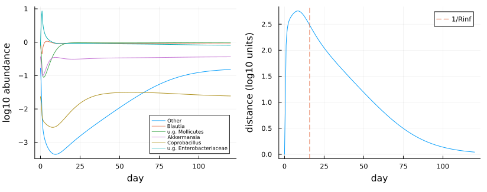

A one-day clindamycin pulse applied to the model’s equilibrium. Left: abundances of the six genera. Right: distance from the equilibrium in log10 units, with the return time 1/Rinf marked.

```julia
times = collect(0:0.25:120.0)
pulse(t) = t < 1 ? 1.0 : 0.0
traj = glv_trajectory(a, ss.N, times; forcing = pulse, susceptibility = ε, tstops = [1.0])
lg(x) = log10.(max.(x, 1e-12))
dist = [norm(lg(traj[k, ss.survivors]) .- lg(ss.N[ss.survivors])) for k in eachindex(times)]
p1 = plot(times, lg(traj[:, ss.survivors]); label = permutedims(short.(genera[ss.survivors])), xlabel = "day",
          ylabel = "log10 abundance", legend = :bottomright, legendfontsize = 6)
p2 = plot(times, dist; label = "", xlabel = "day", ylabel = "distance (log10 units)")
vline!(p2, [1 / m.Rinf]; ls = :dash, label = "1/Rinf")
plot(p1, p2; layout = (1, 2), size = (860, 340))
```

```julia
at(t) = dist[findfirst(==(t), times)]
(peak = maximum(dist), peak_day = times[argmax(dist)], day_23 = at(23.0), day_60 = at(60.0), day_120 = at(120.0))
```

```
(peak = 2.7541835353664137, peak_day = 8.5, day_23 = 2.130166972847733, day_60 = 0.8851348149703921, day_120 = 0.04312846280235173)
```

- **The displacement keeps growing after the pulse ends.** It peaks at about 2.8 log10 units around day 8, the transient amplification that R0 > 0 allows.
- **Recovery takes months.** The community is still 2.1 log10 units away on day 23, the last day observed in the mice, and returns only over the following months.

## Model against observation

For the three clindamycin-only mice, the model is started from each mouse’s observed day-0 state and given the same one-day pulse. The prediction is then compared with the observed abundances on days 2–23.

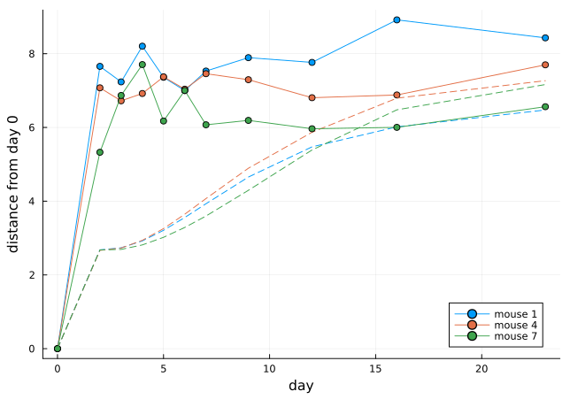

Distance from each mouse’s own day-0 state (log10 units, zeros floored at 10⁻⁶) for the three clindamycin-only mice: observed (solid) and predicted by the fitted model (dashed).

```julia
function mouse_series(mse)
    s = obs[obs.mouse .== mse, :]
    ts = sort(unique(s.time))
    X = [s[(s.time .== t) .& (s.genus .== g), :abundance][1] for t in ts, g in genera]
    return ts, X
end
fl(x; floor = 1e-6) = log10.(max.(x, floor))
plt = plot(; xlabel = "day", ylabel = "distance from day 0", legend = :bottomright)
rows = []
for (k, mse) in enumerate(sort(unique(obs.mouse[obs.group .== 2])))
    ts, X = mouse_series(mse)
    P = glv_trajectory(a, X[1, :], ts; forcing = pulse, susceptibility = ε, tstops = [1.0])
    dO = [norm(fl(X[i, :]) .- fl(X[1, :])) for i in eachindex(ts)]
    dP = [norm(fl(P[i, :]) .- fl(X[1, :])) for i in eachindex(ts)]
    plot!(plt, ts, dO; color = k, marker = :circle, label = "mouse $mse")
    plot!(plt, ts, dP; color = k, ls = :dash, label = "")
    late = ts .>= 2
    o, p = vec(X[late, :]), vec(P[late, :])
    both = (o .> 0) .& (p .> 1e-12)
    push!(rows, (mouse = mse, cor_floor_1e4 = cor(fl(o; floor = 1e-4), fl(p; floor = 1e-4)),
                 cor_floor_1e6 = cor(fl(o), fl(p)), cor_floor_1e8 = cor(fl(o; floor = 1e-8), fl(p; floor = 1e-8)),
                 cor_present_only = cor(log10.(o[both]), log10.(p[both]))))
end
plt
```

```julia
DataFrame(rows)
```

3×5 DataFrame

| Row | mouse Int64 | cor_floor_1e4 Float64 | cor_floor_1e6 Float64 | cor_floor_1e8 Float64 | cor_present_only Float64 |
| --- | --- | --- | --- | --- | --- |
| 1 | 1 | 0.153497 | 0.416137 | 0.632802 | -0.0655451 |
| 2 | 4 | 0.188612 | 0.443774 | 0.653775 | 0.0325784 |
| 3 | 7 | 0.443673 | 0.58727 | 0.723572 | 0.389298 |

- **The observed shift is far larger than predicted.** The mice move 5–8 log10 units from their day-0 state by day 2, while the model moves about 2.7. The observed shift is driven by genera that drop to zero.
- **None recovers by day 23.** The observed communities stay far from day 0. The model drifts further, towards its own equilibrium: the observed day-0 state is not the model’s equilibrium.
- **The correlation between predicted and observed log-abundances measures the zeros, not the fit.**
  - It rises from about 0.15–0.44 to 0.63–0.72 as the floor for zero abundances moves from 10⁻⁴ to 10⁻⁸.
  - Over the genera present in both observation and prediction, it is close to zero for two of the three mice.

## Stability from the time series alone

`smap_jacobians` estimates local Jacobians from a multivariate time series (Deyle et al. 2016), and `invariability` measures temporal stability as mean/sd. Each needs enough data.

**What the S-map needs.**

- **Equally spaced samples.** The mice were sampled on days 0, 2, 3, 4, 5, 6, 7, 9, 12, 16 and 23.
- **More time points than genera plus two.** Each mouse has at most 11 points, for 11 genera.

So the method cannot be applied to these series directly. To see what it would need, apply it to series simulated from the fitted 6-genus community. Each day the community follows the model, and is then multiplied by log-normal process noise (5% on the log scale).

```julia
function noisy(rng, sub, N0, T; σ = 0.05)
    X = zeros(T, length(N0))
    x = copy(N0)
    for t in 1:T
        X[t, :] = x
        x = glv_trajectory(sub, x, [0.0, 1.0])[end, :] .* exp.(σ .* randn(rng, length(x)))
    end
    return X
end
Xsim = noisy(Xoshiro(1), sub, ss.N[ss.survivors], 500)
Js = smap_jacobians(Xsim; theta = 1.0, times = 101:20:481)
long = [resilience(j) for j in Js]
# error of the whole matrix, against the model's Jacobian at the same state
jac_error = [opnorm(j.J - jacobian(sub; N = j.equilibrium).J) / opnorm(jacobian(sub; N = j.equilibrium).J) for j in Js]
short_windows = [resilience(smap_jacobians(Xsim[s:(s + 10), :]; theta = 0.0, times = [10])[1]) for s in 1:10:480]
(true_Rinf = m.Rinf, from_500_days = median(long), relative_error_of_J = median(jac_error),
 from_11_days_median = median(short_windows), from_11_days_range = extrema(short_windows))
```

```
(true_Rinf = 0.06305951806270148, from_500_days = 0.06811233948466101, relative_error_of_J = 0.9268124981741833, from_11_days_median = -0.007026155025189483, from_11_days_range = (-0.5754211286062723, 0.41343949650662937))
```

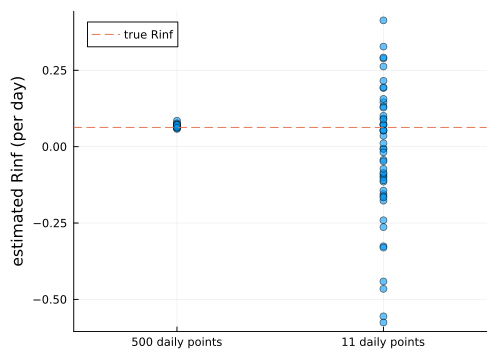

Resilience estimated by the S-map from simulated series: 20 target times in one 500-day series (θ = 1), and 48 separate 11-day windows (θ = 0). The dashed line is the true resilience of the model’s equilibrium.

```julia
plot([fill(1, length(long)); fill(2, length(short_windows))], [long; short_windows]; seriestype = :scatter,
     xticks = ([1, 2], ["500 daily points", "11 daily points"]), xlims = (0.5, 2.5), label = "",
     ylabel = "estimated Rinf (per day)", alpha = 0.6, size = (520, 380))
hline!([m.Rinf]; ls = :dash, label = "true Rinf")
```

- **From 500 daily points**, the S-map recovers the dominant rate of return to within about 10%.
- **The full Jacobian is recovered much less well.** The error in its norm is about as large as the matrix itself: small noise excites some directions too little for their entries to be estimated.
- **From 11 daily points**, the estimates scatter widely around zero: they cannot even tell whether the community is stable.

Invariability needs no model, so it can be computed on the mice directly:

```julia
invtab = combine(groupby(obs, [:mouse, :group]), [:time, :abundance] => ((t, x) -> begin
                  tot = [sum(x[t .== s]) for s in sort(unique(t))]
                  (points = length(tot), invariability = invariability(tot))
              end) => AsTable)
sort!(invtab, [:group, :mouse])
invtab.treatment = getindex.(Ref(Dict(1 => "spores only", 2 => "clindamycin", 3 => "clindamycin + spores")), invtab.group)
invtab
```

9×5 DataFrame

| Row | mouse Int64 | group Int64 | points Int64 | invariability Float64 | treatment String |
| --- | --- | --- | --- | --- | --- |
| 1 | 2 | 1 | 4 | 5.19644 | spores only |
| 2 | 5 | 1 | 4 | 4.70595 | spores only |
| 3 | 8 | 1 | 4 | 2.88673 | spores only |
| 4 | 1 | 2 | 11 | 0.774032 | clindamycin |
| 5 | 4 | 2 | 11 | 1.01702 | clindamycin |
| 6 | 7 | 2 | 11 | 1.17662 | clindamycin |
| 7 | 3 | 3 | 10 | 0.840661 | clindamycin + spores |
| 8 | 6 | 3 | 11 | 1.11215 | clindamycin + spores |
| 9 | 9 | 3 | 11 | 0.975551 | clindamycin + spores |

## Caveats

- **Zeros.** About 9% of the abundances are exactly zero. Log-scale distances and correlations depend on how zeros are floored; this vignette uses 10⁻⁶ and shows the sensitivity.
- **One published fit.** The fit is regularised (Stein et al. 2013, Dataset S1), and its uncertainty is not used here. Refitting is outside the scope of this package.
- **The pulse shape.** The clindamycin signal is 1 on the day of the dose and 0 afterwards. A one-day pulse is the simplest reading of that signal.

## References

- Bucci V. et al. (2016) MDSINE: Microbial Dynamical Systems INference Engine for microbiome time-series analyses. *Genome Biology* 17:121.
- Deyle E.R., May R.M., Munch S.B. & Sugihara G. (2016) Tracking and forecasting ecosystem interactions in real time. *Proc. R. Soc. B* 283:20152258.
- Domínguez-García V., Dakos V. & Kéfi S. (2019) Unveiling dimensions of stability in complex ecological networks. *PNAS* 116:25714–25720.
- Stein R.R. et al. (2013) Ecological modeling from time-series inference: insight into dynamics and stability of intestinal microbiota. *PLoS Comput Biol* 9:e1003388.